# Summarize & filter sequence reads

Zhe Zhang

2016-06-07

**Introduction** This analysis summarizes and filters sequencing reads that have been aligned to the reference based on SAM fields such as *FLAG*, *MAPQ*, and *CIGAR*. It uses the readGAlignments (single-ended reads) and readGAlignmentPairs (pair-ended reads) to import aligned reads from indexed BAM files. Summary statistics of imported reads are compared between samples for consistence and potential outliers. These statistics are

- *strand balance:* reads mapped to forward vs. reverse strands
- *mapping flag:* a single bitwise value that summarizes the alignment result of each read
- *mapping quality:* p value of mapping certainty assigned by the aligment program
- *base count:* number of bases in each read with insertion, getting trimmed, etc. (CIGAR operations)
- *matching length:* total number of bases in each read matching to the reference

Finally, the reads will be filtered based on given criteria covering 4 possible rules:

- *mapping region:* reads must be mapped to given genomic region(s)
- *mapping flag:* the SAM field *FLAG* must have one of given values
- *mapping quality:* the SAM field *MAPQ* must have value greater than or equal to a given value
- *matching length:* the total number of bases matching the reference must be greater than or equal to a given value

*[Go to project home](http://zhezhangsh.github.io/RoCA)*

# 1 Description

## 1.1 Project

[1000 Genomes Project](http://www.1000genomes.org)

## 1.2 Experiment

The goal of the 1000 Genomes Project was to find most genetic variants with frequencies of at least 1% in the populations studied.

## 1.3 Analysis

This analysis is a testing that fetches, summarizes, and filters sequencing reads of 1000 Genomes samples mapped to a few small genomic regions. It can be used as an example to fetch a small number of reads from all 1000 Genomes samples. To routinely run this analysis, it’s strongly recommended to download and save all .bai files, so they can be reused.

*[Go to project home](http://zhezhangsh.github.io/RoCA)*

# 2 Summary statistics

## 2.1 Mapping *FLAG*

Each alignment software could assign a bitwise value as a combination of FLAGs to each read to represent the result of the alignment, as descrbed in [SAM format manual](https://samtools.github.io/hts-specs/SAMv1.pdf), Section 1.4. The bitwise value is 0 if the read is aligned “normally” and uniquely to the forward strand, and is 16 if the read is aligned “normally” and uniquely to the reverse strand. Any other values would suggest that there is something “wrong” with the alignment. The majority of the alignment will assign a strand to the read, but in some rare occasions, the strand is ambiguous and there is no strand information available for the read. Click here to view the summary statistics about the FLAGs and alignment strands.

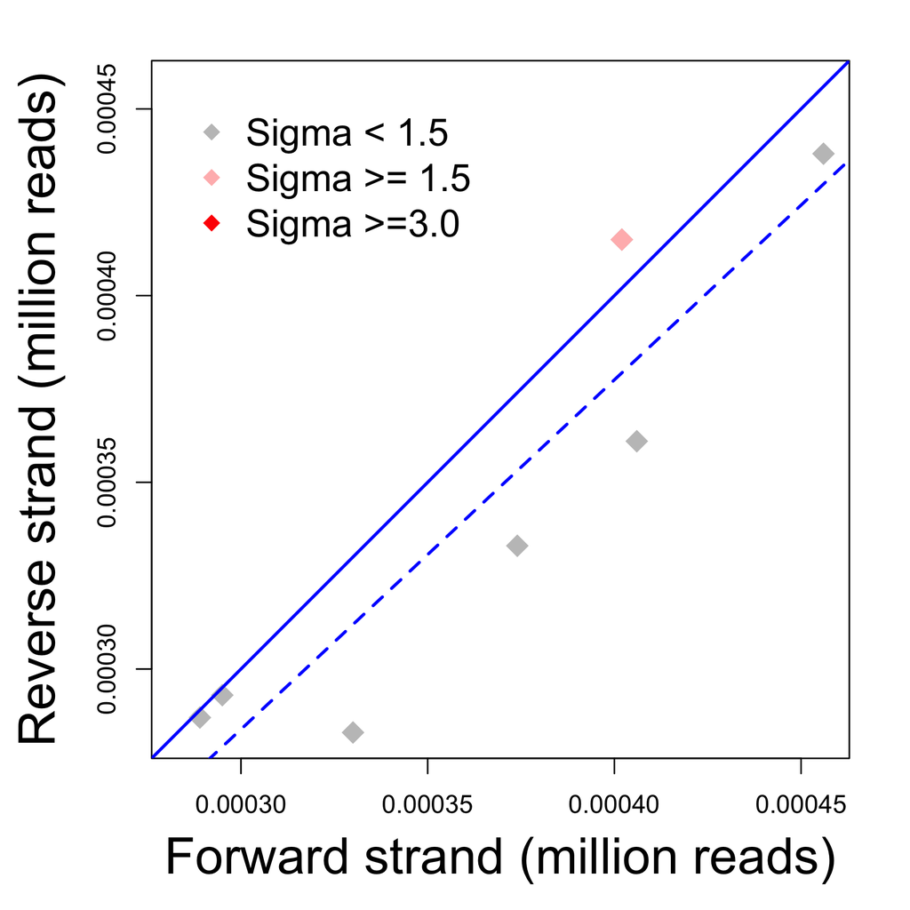

*[Go to project home](http://zhezhangsh.github.io/RoCA)*

## 2.2 Mapping quality *MAPQ*

Each alignment software could use its own algorithm to assign an alignment score to each align reads. The scores are usually non-negative integers, with 0 corresponding to the lowest mapping quality.

- Number of reads with each MAPQ score
- Percent of reads with each MAPQ score

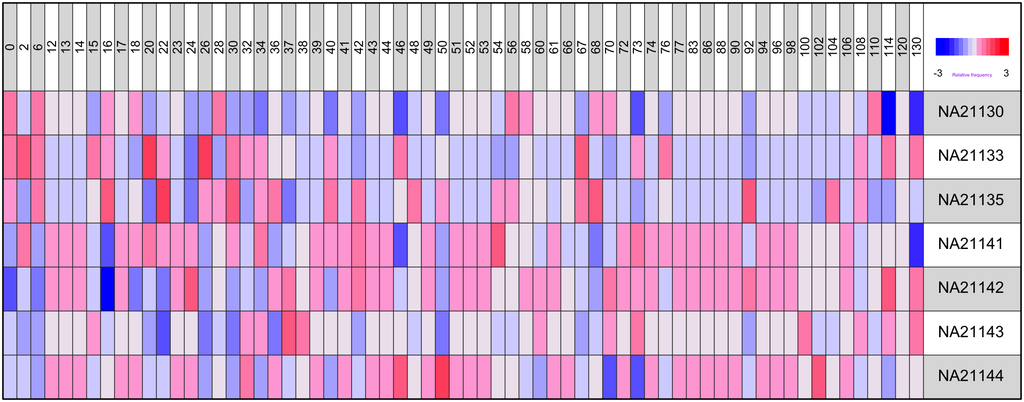

**Figure 2** Each cell indicates the relative frequency of reads with a given mapping score, comparing to all the other samples.

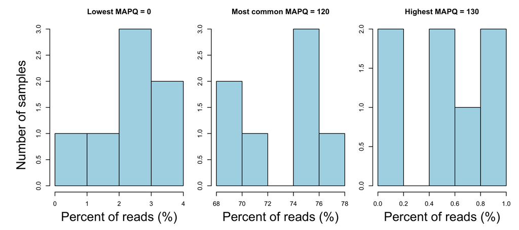

**Figure 3** Each plot shows the distribution of read frequencies with the lowest, highest, and the most common mapping quality scores.

*[Go to project home](http://zhezhangsh.github.io/RoCA)*

## 2.3 *CIGAR* operations

CIGAR string indicates the internal structure of each alignment such as the base where insertion or deletion starts. By breaking CIGAR string of each read, bases belonging to each CIGAR operation was counted:

- Number of bases with each CIGAR operation
- Percent of bases with CIGAR operation

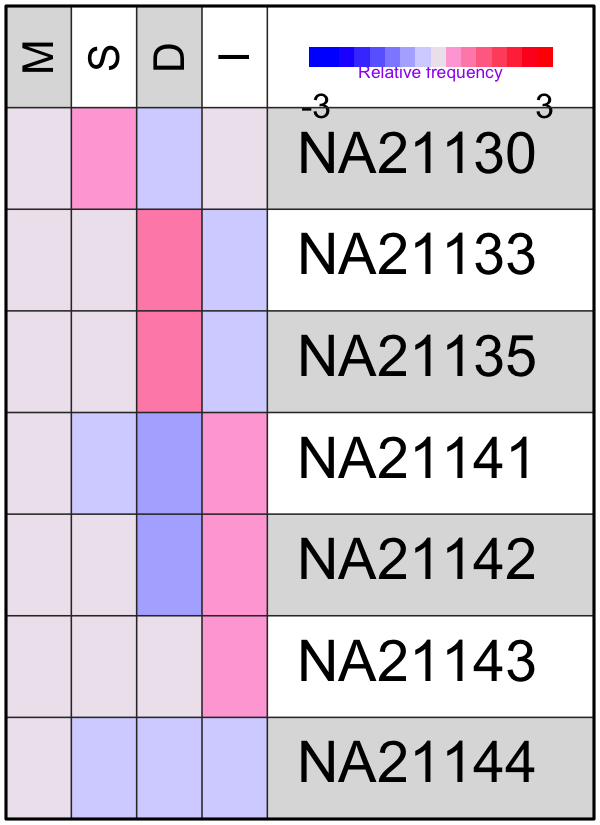

**Figure 4** Each cell indicates the relative frequency of reads with a given character in their CIGAR strings, comparing to all the other samples.

*[Go to project home](http://zhezhangsh.github.io/RoCA)*

## 2.4 Matching length

The matching length (total number of matched bases) of each read can be retrieved from the *M* operation in its CIGAR string. Matching length of all reads in each library was summarized to get the cummulative percents of reads with matching length no greater than a given number of bases.

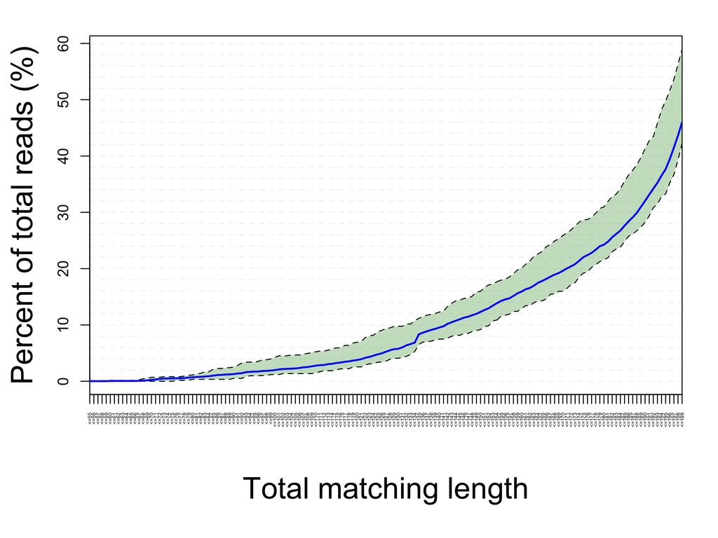

**Figure 5** Cummulative percent of sequence reads with matching length no greater than a given number. Blue line is the average of all libraries whereas the dashed lines correspond to the minimum and maximum of all libraries. This plot roughly indicates the proportion of reads that will be filtered out with each cutoff value of matching length.

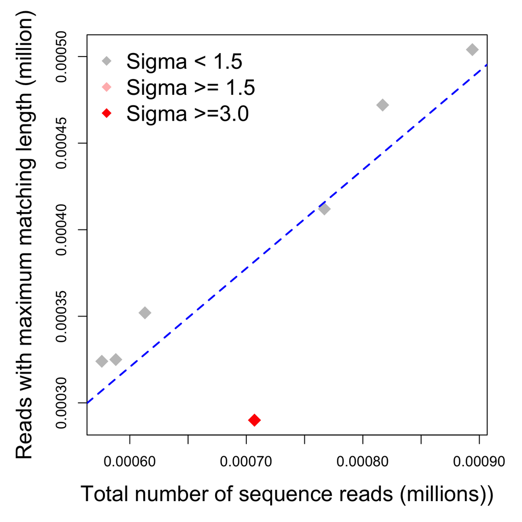

**Figure 6** Numbers of total reads vs. the reads with longest matching length in each library. Outliers were identified via fitting linear models (Sigma > 3.0). The blue lines is the fitting to the linear model using all libraries.

*[Go to project home](http://zhezhangsh.github.io/RoCA)*

# 3 Read filtering

## 3.1 Step-by-step filtering

Sequence reads were filtered by the following steps to keep those

- mapped to these genomic regions
- with the *FLAG* field of SAM format having one of these values: *83; 99*.
- with the *MAPQ* field of SAM format having values greater than or equal to *20, 30*.
- with at least *20, 30* mapped bases based on the *CIGAR* field of SAM format.

The details about SAM format can be found [here](https://samtools.github.io/hts-specs/SAMv1.pdf).

The number and percent of remaining reads after each filter step are listed here and here.

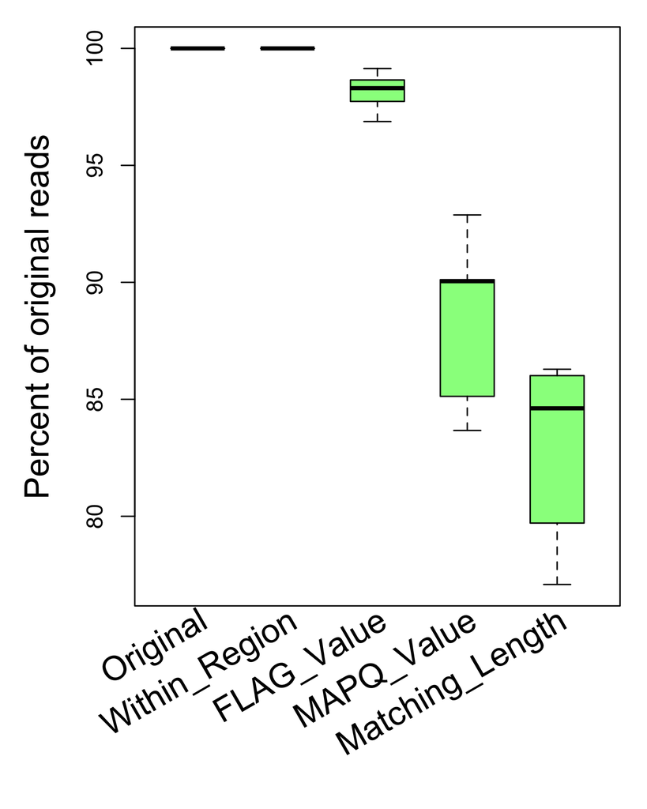

**Figure 7.** Each box represents the distribution of remaining read percents of all samples.

*[Go to project home](http://zhezhangsh.github.io/RoCA)*

## 3.2 Final filtering result

The final remaining percents of original reads after all filtering steps were compared between samples. The numbers of reads before and after filtering were fit to a linear regression based on the assumption that all samples had the same remaining percent. Using this model, the sigma value of each sample was calculated as the difference between predicted and actual numbers of remaining reads. Samples with sigmas greater than 3.0 could be considered as outliers with extraordinarily low or high remaining percent. Click here to see the result table.

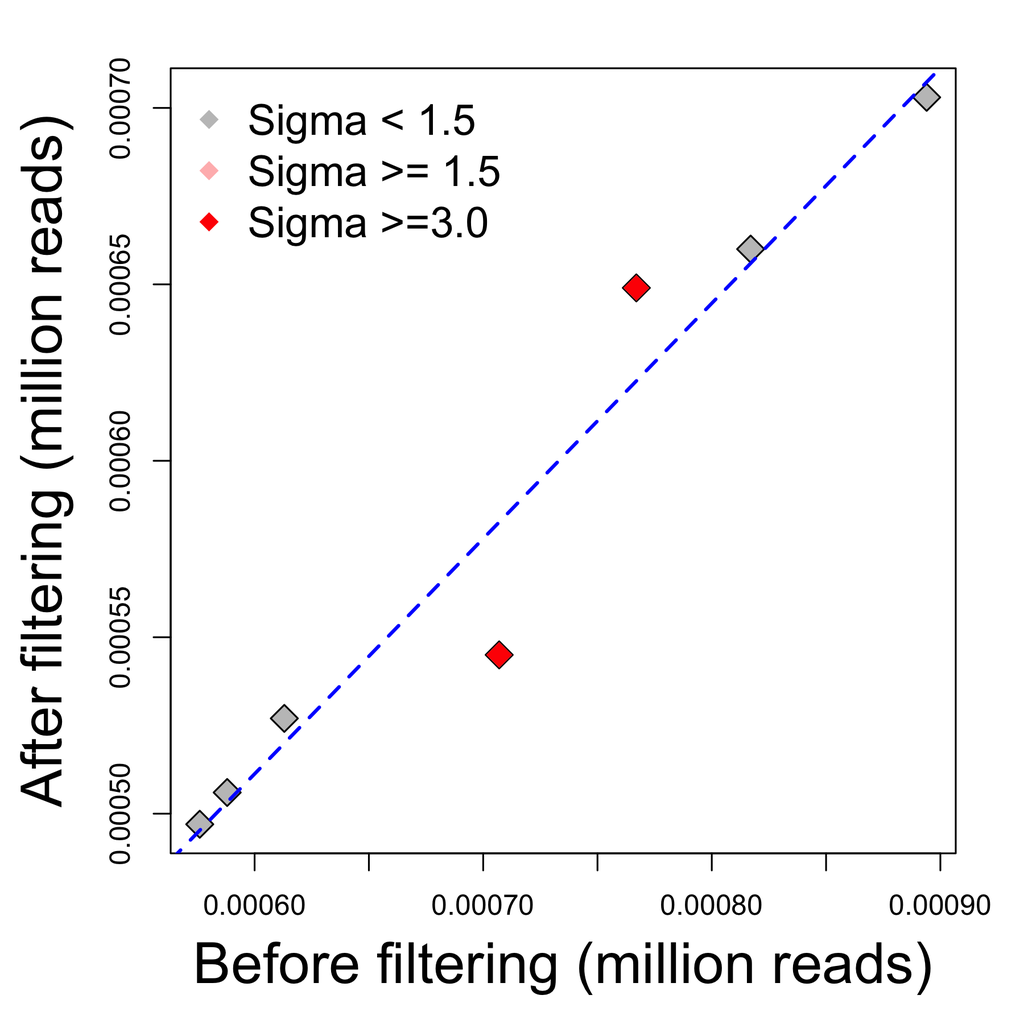

**Figure 8** Numbers of reads before and after filtering.

*[Go to project home](http://zhezhangsh.github.io/RoCA)*

# 4 Appendix

Check out the **[RoCA home page](http://zhezhangsh.github.io/RoCA)** for more information.

## 4.1 Reproduce this report

To reproduce this report:

1. Find the data analysis template you want to use and an example of its pairing YAML file [here](https://github.com/zhezhangsh/RoCA/wiki/Templates-and-examples) and download the YAML example to your working directory
2. To generate a new report using your own input data and parameter, edit the following items in the YAML file:
- *output* : where you want to put the output files
- *home* : the URL if you have a home page for your project
- *analyst* : your name
- *description* : background information about your project, analysis, etc.
- *input* : where are your input data, read instruction for preparing them
- *parameter* : parameters for this analysis; read instruction about how to prepare input data
3. Run the code below within *R Console* or *RStudio*, preferablly with a new R session:

```r
if (!require(devtools)) { install.packages('devtools'); require(devtools); }
if (!require(RCurl)) { install.packages('RCurl'); require(RCurl); }
if (!require(RoCA)) { install_github('zhezhangsh/RoCAR'); require(RoCA); }

CreateReport(filename.yaml);  # filename.yaml is the YAML file you just downloaded and edited for your analysis
```

If there is no complaint, go to the *output* folder and open the *index.html* file to view report.

*[Go to project home](http://zhezhangsh.github.io/RoCA)*

**END_OF_DOCUMENT**